# ANOVA

Independent factorial

Klinkenberg

10 oct 2019

# Independent factorial ANOVA

Two or more independent variables with two or more categories. One dependent variable.

## Independent factorial ANOVA

The independent factorial ANOVA analyses the variance of multiple independent variables (Factors) with two or more categories.

Effects and interactions:

- 1 dependent/outcome variable
- 2 or more independent/predictor variables
  - 2 or more cat./levels

## Assumptions

- Continuous variable
- Random sample
- Normaly distributed
  - Shapiro-Wilk test
- Equal variance within groups
  - Levene’s test

## Formulas

| Variance | Sum of squares | df | Mean squares | F-ratio |
| --- | --- | --- | --- | --- |
| Model | $\text{SS}_{\text{model}} = \sum{n_k(\bar{X}_k-\bar{X})^2}$ | $k_{model}-1$ | $\frac{\text{SS}_{\text{model}}}{\text{df}_{\text{model}}}$ | $\frac{\text{MS}_{\text{model}}}{\text{MS}_{\text{error}}}$ |
| $\hspace{2ex}A$ | $\text{SS}_{\text{A}} = \sum{n_k(\bar{X}_k-\bar{X})^2}$ | $k_A-1$ | $\frac{\text{SS}_{\text{A}}}{\text{df}_{\text{A}}}$ | $\frac{\text{MS}_{\text{A}}}{\text{MS}_{\text{error}}}$ |
| $\hspace{2ex}B$ | $\text{SS}_{\text{B}} = \sum{n_k(\bar{X}_k-\bar{X})^2}$ | $k_B-1$ | $\frac{\text{SS}_{\text{B}}}{\text{df}_{\text{B}}}$ | $\frac{\text{MS}_{\text{B}}}{\text{MS}_{\text{error}}}$ |
| $\hspace{2ex}AB$ | $\text{SS}_{A \times B} = \text{SS}_{\text{model}} - \text{SS}_{\text{A}} - \text{SS}_{\text{B}}$ | $df_A \times df_B$ | $\frac{\text{SS}_{\text{AB}}}{\text{df}_{\text{AB}}}$ | $\frac{\text{MS}_{\text{AB}}}{\text{MS}_{\text{error}}}$ |
| Error | $\text{SS}_{\text{error}} = \sum{s_k^2(n_k-1)}$ | $N-k_{model}$ | $\frac{\text{SS}_{\text{error}}}{\text{df}_{\text{error}}}$ |  |
| Total | $\text{SS}_{\text{total}} = \text{SS}_{\text{model}} + \text{SS}_{\text{error}}$ | $N-1$ | $\frac{\text{SS}_{\text{total}}}{\text{df}_{\text{total}}}$ |  |

## Example

In this example we will look at the amount of accidents in a car driving simulator while subjects where given varying doses of speed and alcohol.

- Dependent variable
  - Accidents
- Independent variables
  - Speed
    - None
    - Small
    - Large
  - Alcohol
    - None
    - Small
    - Large

| person | alcohol | speed | accidents |
| --- | --- | --- | --- |
| 1 | 1 | 1 | 0 |
| 2 | 1 | 2 | 2 |
| 3 | 1 | 3 | 4 |
| 4 | 2 | 1 | 6 |
| 5 | 2 | 2 | 8 |
| 6 | 2 | 3 | 10 |
| 7 | 3 | 1 | 12 |
| 8 | 3 | 2 | 14 |
| 9 | 3 | 3 | 16 |

## Data

|  | subjects | gender | alcohol | speed | accidents | weight |
| --- | --- | --- | --- | --- | --- | --- |
| 1 | 1 | male | none | none | 2.67 | 70.29 |
| 2 | 2 | female | none | none | 2.64 | 66.44 |
| 3 | 3 | male | none | none | 2.39 | 59.2 |
| 4 | 4 | female | none | none | 2.13 | 58.86 |
| 5 | 5 | male | none | none | 2.16 | 77.26 |
| 6 | 6 | female | none | none | 2.33 | 81.83 |
| 7 | 7 | male | none | none | 1.79 | 70.88 |
| 8 | 8 | female | none | none | 2.37 | 52.06 |
| 9 | 9 | male | none | none | 1.91 | 72.28 |
| 10 | 10 | female | none | none | 1.78 | 67.53 |

[output cut: 170 more lines]

## SS<sub>model</sub>

| Variance | Sum of squares | df | Mean squares | F-ratio |
| --- | --- | --- | --- | --- |
| Model | $\text{SS}_{\text{model}} = \sum{n_k(\bar{X}_k-\bar{X})^2}$ | $k_{model}-1$ | $\frac{\text{SS}_{\text{model}}}{\text{df}_{\text{model}}}$ | $\frac{\text{MS}_{\text{model}}}{\text{MS}_{\text{error}}}$ |

```
##   speed alcohol accidents  n
## 1  much    much    7.5720 20
## 2  none    much    5.2970 20
## 3  some    much    6.5125 20
## 4  much    none    3.8880 20
## 5  none    none    2.1060 20
## 6  some    none    2.9445 20
## 7  much    some    5.5790 20
## 8  none    some    3.4435 20
## 9  some    some    4.7625 20
```

|  | data.speed | data.alcohol | accidents | grand.mean | group.mean |
| --- | --- | --- | --- | --- | --- |
| 1 | none | none | 2.67 | 4.68 | 2.11 |
| 2 | none | none | 2.64 | 4.68 | 2.11 |
| 3 | none | none | 2.39 | 4.68 | 2.11 |
| 4 | none | none | 2.13 | 4.68 | 2.11 |
| 5 | none | none | 2.16 | 4.68 | 2.11 |
| 6 | none | none | 2.33 | 4.68 | 2.11 |
| 7 | none | none | 1.79 | 4.68 | 2.11 |
| 8 | none | none | 2.37 | 4.68 | 2.11 |
| 9 | none | none | 1.91 | 4.68 | 2.11 |
| 10 | none | none | 1.78 | 4.68 | 2.11 |

[output cut: 170 more lines]

```r
SS.model <- sum((exp.accidents - mean(data$accidents))^2); SS.model
```

```
## [1] 494.2205
```

```r
m.k1 = mean(subset(data, speed == "none" & alcohol == "none", select = "accidents")$accidents)
m.k2 = mean(subset(data, speed == "none" & alcohol == "some", select = "accidents")$accidents)
m.k3 = mean(subset(data, speed == "none" & alcohol == "much", select = "accidents")$accidents)
m.k4 = mean(subset(data, speed == "some" & alcohol == "none", select = "accidents")$accidents)
m.k5 = mean(subset(data, speed == "some" & alcohol == "some", select = "accidents")$accidents)
m.k6 = mean(subset(data, speed == "some" & alcohol == "much", select = "accidents")$accidents)
m.k7 = mean(subset(data, speed == "much" & alcohol == "none", select = "accidents")$accidents)
m.k8 = mean(subset(data, speed == "much" & alcohol == "some", select = "accidents")$accidents)
m.k9 = mean(subset(data, speed == "much" & alcohol == "much", select = "accidents")$accidents)

n.k1 = n.k2 = n.k3 = n.k4 = n.k5 = n.k6 = n.k7 = n.k8 = n.k9 = 20
```

```r
ss.m.k1 = n.k1 * (m.k1 - mean(accidents))^2
ss.m.k2 = n.k2 * (m.k2 - mean(accidents))^2
ss.m.k3 = n.k3 * (m.k3 - mean(accidents))^2
ss.m.k4 = n.k4 * (m.k4 - mean(accidents))^2
ss.m.k5 = n.k5 * (m.k5 - mean(accidents))^2
ss.m.k6 = n.k6 * (m.k6 - mean(accidents))^2
ss.m.k7 = n.k7 * (m.k7 - mean(accidents))^2
ss.m.k8 = n.k8 * (m.k8 - mean(accidents))^2
ss.m.k9 = n.k9 * (m.k9 - mean(accidents))^2

ss.model = sum(ss.m.k1,ss.m.k2,ss.m.k3,ss.m.k4,ss.m.k5,ss.m.k6,ss.m.k7,ss.m.k8,ss.m.k9)
ss.model
```

```
## [1] 494.2205
```

## SS<sub>model</sub> visual

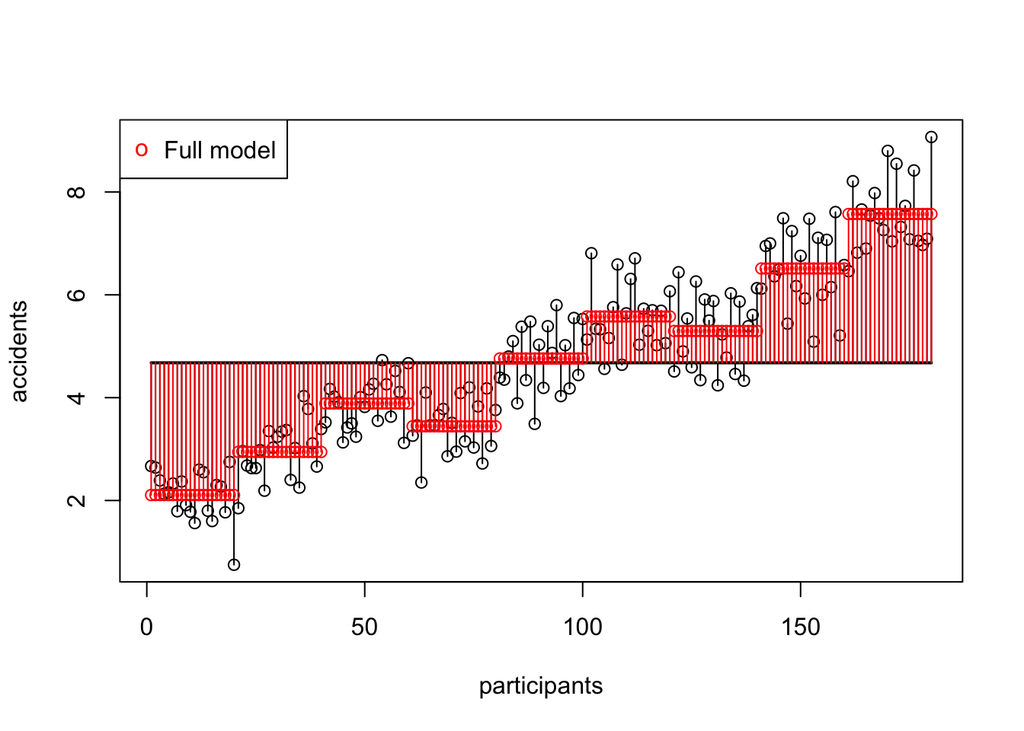

```r
# Plot all data points
plot(accidents,
     xlab = 'participants')

# With the mean
lines(1:n,rep(mean(accidents),n),col='black',lwd=2)

# The black lines are the total variance, the deviation from the mean.
segments(1:n, mean(accidents), 1:n, accidents)

# The model predicts the accidents scores
points(1:n,exp.accidents, col='red')

p <- recordPlot()

# The black lines are the total variance, the deviation from the mean.
segments(1:n, exp.accidents, 1:n, mean(accidents), col = "red")

# Add legend to plot
legend("topleft",
       pch    = c("o"),
       col    = c("red"),
       legend = c("Full model") )
```

## SS<sub>error</sub>

| Variance | Sum of squares | df | Mean squares | F-ratio |
| --- | --- | --- | --- | --- |
| Error | $\text{SS}_{\text{error}} = \sum{s_k^2(n_k-1)}$ | $N-k$ | $\frac{\text{SS}_{\text{error}}}{\text{df}_{\text{error}}}$ |  |

```r
v.k1 = var(subset(data, speed == "none" & alcohol == "none", select = "accidents")$accidents)
v.k2 = var(subset(data, speed == "none" & alcohol == "some", select = "accidents")$accidents)
v.k3 = var(subset(data, speed == "none" & alcohol == "much", select = "accidents")$accidents)
v.k4 = var(subset(data, speed == "some" & alcohol == "none", select = "accidents")$accidents)
v.k5 = var(subset(data, speed == "some" & alcohol == "some", select = "accidents")$accidents)
v.k6 = var(subset(data, speed == "some" & alcohol == "much", select = "accidents")$accidents)
v.k7 = var(subset(data, speed == "much" & alcohol == "none", select = "accidents")$accidents)
v.k8 = var(subset(data, speed == "much" & alcohol == "some", select = "accidents")$accidents)
v.k9 = var(subset(data, speed == "much" & alcohol == "much", select = "accidents")$accidents)
```

```r
ss.e.k1 = v.k1 * (n.k1 - 1)
ss.e.k2 = v.k2 * (n.k2 - 1)
ss.e.k3 = v.k3 * (n.k3 - 1)
ss.e.k4 = v.k4 * (n.k4 - 1)
ss.e.k5 = v.k5 * (n.k5 - 1)
ss.e.k6 = v.k6 * (n.k6 - 1)
ss.e.k7 = v.k7 * (n.k7 - 1)
ss.e.k8 = v.k8 * (n.k8 - 1)
ss.e.k9 = v.k9 * (n.k9 - 1)

ss.error = sum(ss.e.k1,ss.e.k2,ss.e.k3,ss.e.k4,ss.e.k5,ss.e.k6,ss.e.k7,ss.e.k8,ss.e.k9)
ss.error
```

```
## [1] 66.34642
```

## SS<sub>error</sub> visual

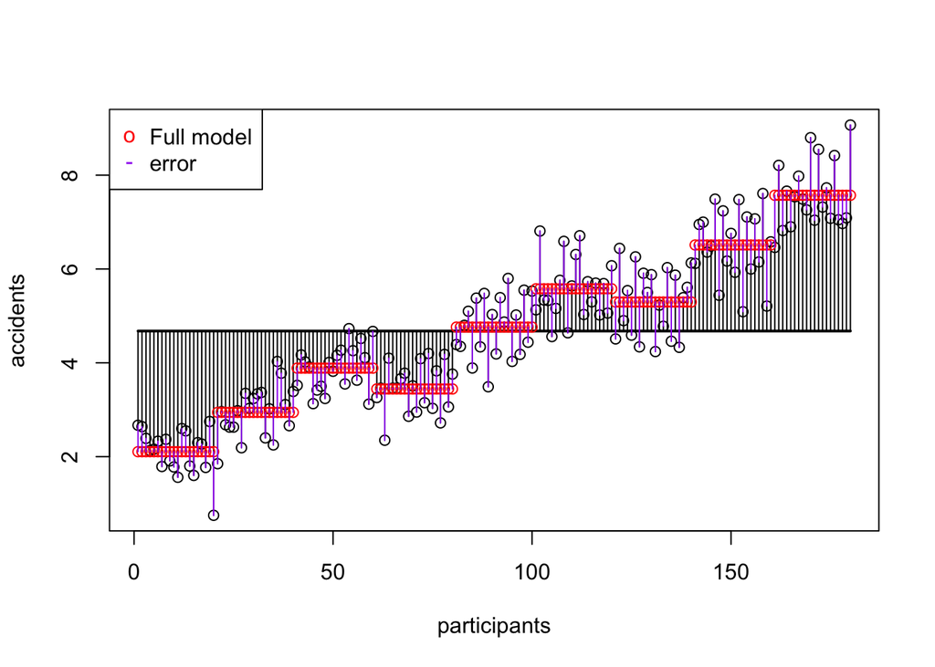

```r
p

# Now we can add the error of this model
segments(1:n, accidents, 1:n, exp.accidents, col='purple')

# Add legend to plot
legend("topleft",
       pch    = c("o", "-"),
       col    = c("red", "purple"),
       legend = c("Full model", "error") )
```

## SS<sub>A</sub> Speed

| Variance | Sum of squares | df | Mean squares | F-ratio |
| --- | --- | --- | --- | --- |
| $\hspace{2ex}A$ | $\text{SS}_{\text{A}} = \sum{n_k(\bar{X}_k-\bar{X})^2}$ | $k_A-1$ | $\frac{\text{SS}_{\text{A}}}{\text{df}_{\text{A}}}$ | $\frac{\text{MS}_{\text{A}}}{\text{MS}_{\text{error}}}$ |

```r
m.s1 = mean(subset(data, speed == "none", select = "accidents")$accidents)
m.s2 = mean(subset(data, speed == "some", select = "accidents")$accidents)
m.s3 = mean(subset(data, speed == "much", select = "accidents")$accidents)

n.s1 = n.s2 = n.s3 = 60
```

```r
ss.s1 = n.s1 * (m.s1 - mean(accidents))^2
ss.s2 = n.s2 * (m.s2 - mean(accidents))^2
ss.s3 = n.s3 * (m.s3 - mean(accidents))^2

ss.speed = sum(ss.s1,ss.s2,ss.s3)
ss.speed
```

```
## [1] 128.1639
```

## SS<sub>A</sub> Speed Visual

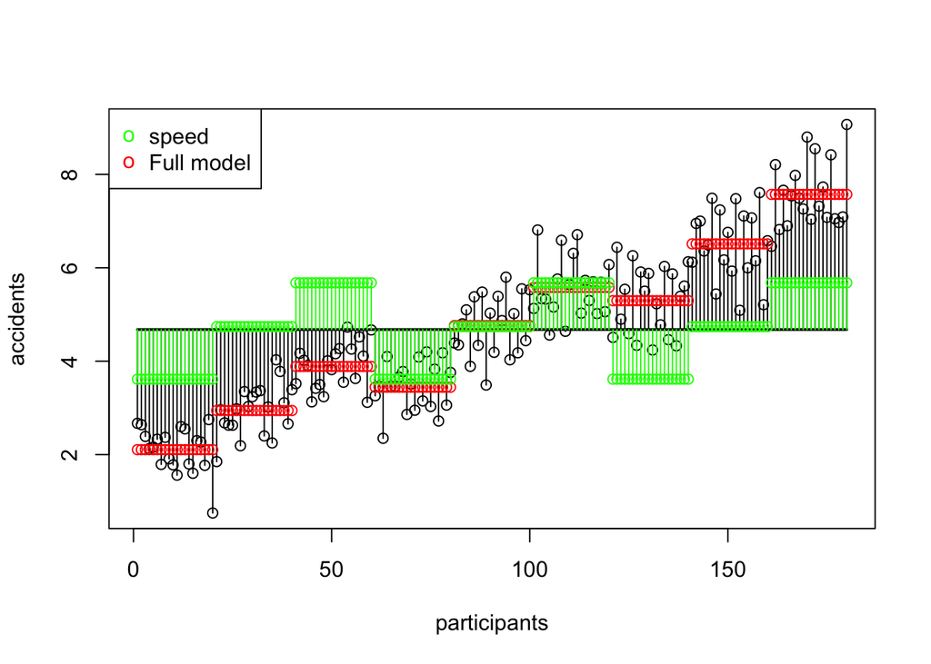

```r
p
# Deviation of speed
points(1:n, data$means.speed,  col='green')
segments(1:n, mean(accidents), 1:n, data$means.speed, col='green')

# Add legend to plot
legend("topleft",
       pch    = c("o", "o"),
       col    = c("green", "red"),
       legend = c("speed", "Full model") )
```

## SS<sub>B</sub> Alcohol

| Variance | Sum of squares | df | Mean squares | F-ratio |
| --- | --- | --- | --- | --- |
| $\hspace{2ex}B$ | $\text{SS}_{\text{B}} = \sum{n_k(\bar{X}_k-\bar{X})^2}$ | $k_B-1$ | $\frac{\text{SS}_{\text{B}}}{\text{df}_{\text{B}}}$ | $\frac{\text{MS}_{\text{B}}}{\text{MS}_{\text{error}}}$ |

```r
m.a1 = mean(subset(data, alcohol == "none", select = "accidents")$accidents)
m.a2 = mean(subset(data, alcohol == "some", select = "accidents")$accidents)
m.a3 = mean(subset(data, alcohol == "much", select = "accidents")$accidents)

n.a1 = n.a2 = n.a3 = 60
```

```r
ss.a1 = n.a1 * (m.a1 - mean(accidents))^2
ss.a2 = n.a2 * (m.a2 - mean(accidents))^2
ss.a3 = n.a3 * (m.a3 - mean(accidents))^2

ss.alcohol = sum(ss.a1,ss.a2,ss.a3)
ss.alcohol
```

```
## [1] 364.1458
```

## SS<sub>B</sub> Alcohol Visual

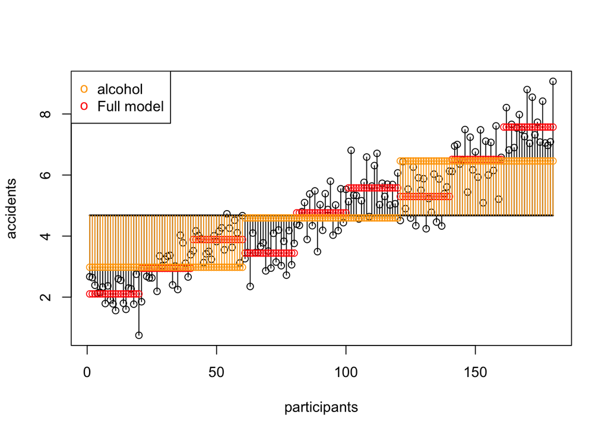

```r
p

# Deviation of alcohol
points(1:n, data$means.alcohol,col='orange',type="p")
segments(1:n, mean(accidents), 1:n, data$means.alcohol, col='orange')

# Add legend to plot
legend("topleft",
       pch    = c("o", "o"),
       col    = c("orange", "red"),
       legend = c("alcohol", "Full model") )
```

## SS<sub>AB</sub> Alcohol x Speed

| Variance | Sum of squares | df | Mean squares | F-ratio |
| --- | --- | --- | --- | --- |
| $\hspace{2ex}AB$ | $\text{SS}_{A \times B} = \text{SS}_{\text{model}} - \text{SS}_{\text{A}} - \text{SS}_{\text{B}}$ | $df_A \times df_B$ | $\frac{\text{SS}_{\text{AB}}}{\text{df}_{\text{AB}}}$ | $\frac{\text{MS}_{\text{AB}}}{\text{MS}_{\text{error}}}$ |

```r
# Sums of squares for the interaction between speed and alcohol
ss.speed.alcohol <- ss.model - ss.speed - ss.alcohol
ss.speed.alcohol
```

```
## [1] 1.910727
```

## Mean Squares

Mean squares for:

- Speed
- Alcohol
- Speed $\times$ Alcohol

$$\begin{aligned}
F_{Speed} &= \frac{{MS}_{Speed}}{{MS}_{error}} \\
F_{Alcohol} &= \frac{{MS}_{Alcohol}}{{MS}_{error}} \\
F_{Alcohol \times Speed} &= \frac{{MS}_{Alcohol \times Speed}}{{MS}_{error}} \\
\end{aligned}$$

## Interaction

$$F_{Alcohol \times Speed}$$

```r
N          = length(accidents)
k.speed    = 3
k.alcohol  = 3
k.model    = 9
df.speed   = k.speed   - 1
df.alcohol = k.alcohol - 1
df.speed.alcohol = df.speed * df.alcohol

ms.speed.alcohol = ss.speed.alcohol / df.speed.alcohol

df.error = N - k.model
ms.error = ss.error / df.error
```

## $P$-value

```r
F.speed.alcohol = ms.speed.alcohol / ms.error
F.speed.alcohol
```

```
## [1] 1.231168
```

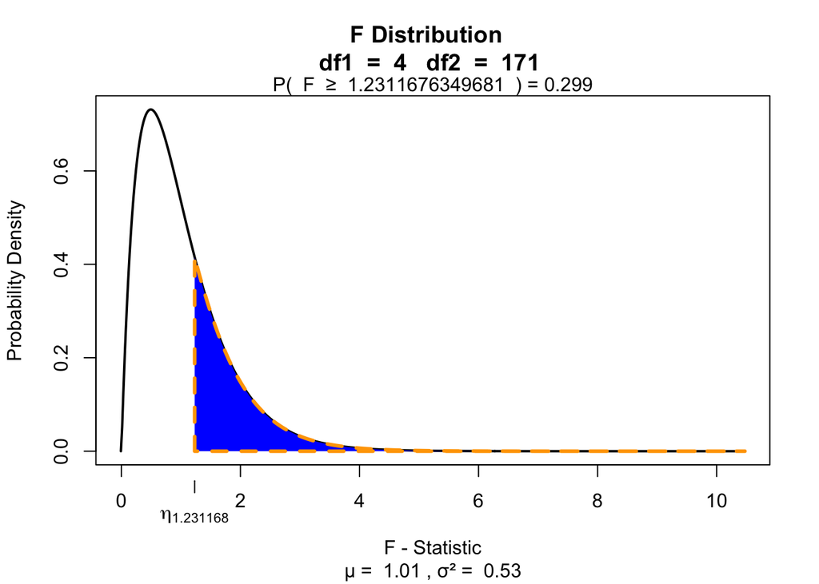

```r
library(visualize)
visualize.f(F.speed.alcohol, df.speed.alcohol, df.error, section = "upper")
```

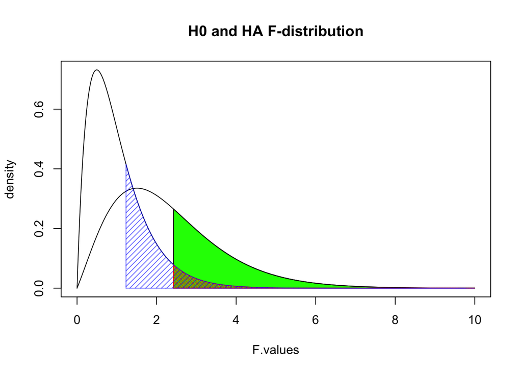

```r
F.values = seq(0, 10, .01)

plot(F.values, df(F.values, df.speed.alcohol, df.error), type = "l", ylab="density", main = "H0 and HA F-distribution")

critical.value = qf(.95, df.speed.alcohol, df.error)

critical.range = seq(critical.value, 10, .01)

polygon(c(critical.range,rev(critical.range)),
        c(critical.range*0, rev(df(critical.range, df.speed.alcohol, df.error, ncp = 5))), col = "green")

lines(F.values, df(F.values, df.speed.alcohol, df.error, ncp = 5))

polygon(c(critical.range,rev(critical.range)),
        c(critical.range*0, rev(df(critical.range, df.speed.alcohol, df.error))), col = rgb(1,0,0,1), density = 40, angle = -45)

p.range = seq(F.speed.alcohol, 10, .01)

polygon(c(p.range,rev(p.range)),
        c(p.range*0, rev(df(p.range, df.speed.alcohol, df.error))), col = rgb(0,0,1,.6), density = 20)
```

## Contrast

Planned comparisons

- Exploring differences of theoretical interest
- Higher precision
- Higher power

## Post-Hoc

Unplanned comparisons

- Exploring all possible differences
- Adjust T value for inflated type 1 error

## Effect size

General effect size measures

- Amount of explained variance $R^2$ also called eta squared $\eta^2$.
- Omega squared $\omega^2$

Effect sizes of contrasts or post-hoc comparisons

- Cohen’s $r$ gives the effect size for a specific comparison
  - $r_{Contrast} = \sqrt{\frac{t^2}{t^2+{df}}}$

# End

- [@shklinkenberg](https://twitter.com/shklinkenberg)
- [Klinkenberg](https://www.linkedin.com/in/sharonklinkenberg/)
- ln.AvU@grebneknilK.S
- ShKlinkenberg